## Assignment 6

#### Due Sunday, March 26, 11:59 PM CT

### Preliminaries

- Directories
  - COURSE/homework/
  - COURSE/homework/hw06/
  - COURSE/data/
  - COURSE/scripts/
- Files
  - COURSE/homework/hw06/hw06.Rmd
  - COURSE/data/exoplanets-clean-through-2022.csv
  - COURSE/data/wordle.csv
  - COURSE/scripts/viridis.R

### Aims

- Practice strings and regular expressions

### Problems

Problems 1–4 are based on a data frame with the names of built-in R colors.

```r
df_colors = tibble(color = colors()) %>%
  mutate(index = row_number(), .before = color)
```

1. Create a data frame with the names of all colors whose names are exactly 7 characters long. Print a summary of this data frame with the number of colors and the first and last alphabetically in the list.

```r
seven_characters = df_colors %>%
  filter(str_length(color) == 7) %>%
  arrange(color)

seven_characters %>%
  summarize(n = nrow(seven_characters), first = first(color), last = last(color)) %>%
  print()
```

```
## # A tibble: 1 × 3
##       n first   last
##   <int> <chr>   <chr>
## 1    46 bisque1 yellow4
```

2. How many of the previous color names contain no digits? Create a second data frame which eliminates the rows from your solution to the previous problem any color names which contain a digit. Print a summary of this data frame with the number of colors and the first and last alphabetically in the list.

```r
no_digits = seven_characters %>%
    filter(is.na(str_extract(color,"\\d"))) %>%
  arrange(color)

no_digits %>%
  summarize(n = nrow(no_digits), first = first(color), last = last(color)) %>%
  print()
```

```
## # A tibble: 1 × 3
##       n first   last
##   <int> <chr>   <chr>
## 1     8 darkred thistle
```

3. Find all colors which contain consecutive letters “e”. Print a summary with a count of how many such colors there are and the first and last alphabetically.

```r
ee = df_colors %>%
  filter(str_detect(color, "ee")) %>%
  arrange(color)

ee %>%
  summarize(count = nrow(ee), first = first(color), last = last(color)) %>%
  print()
```

```
## # A tibble: 1 × 3
##   count first     last
##   <int> <chr>     <chr>
## 1    60 darkgreen yellowgreen
```

4. Find all color names which contain any consecutive identical letters. Create a data frame with these colors.
- Print the first ten rows of this data frame
- Tabulate how often each letter is used in a consecutive letter pair and print out this table arranged in descending order of the counts.
- Identify the three color names which have a distinct pair of consecutive identical letters. (These are the only color names which use the given letter pair.)

```r
consec = df_colors %>%
  filter(str_detect(color, "(.)\\1")) %>%
  arrange(color)

consec %>%
  print(n = 10)
```

```
## # A tibble: 124 × 2
##    index color
##    <int> <chr>
##  1    37 burlywood
##  2    38 burlywood1
##  3    39 burlywood2
##  4    40 burlywood3
##  5    41 burlywood4
##  6    81 darkgreen
##  7    83 darkkhaki
##  8    85 darkolivegreen
##  9    86 darkolivegreen1
## 10    87 darkolivegreen2
## # … with 114 more rows
```

```r
letter_counts = table(pair = str_extract(consec$color, "(.)\\1")) %>%
  sort(decreasing = TRUE)

letter_counts %>%
  print()
```

```
## pair
## ee ll ff oo gg nn 00 11 22 33 44 55 66 77 88 99 cc dd kk
## 53 17 10 10  6  5  2  2  2  2  2  2  2  2  2  2  1  1  1
```

```r
distinct_pair = df_colors %>%
  filter(str_detect(color, "cc") | str_detect(color, "dd") | str_detect(color, "kk"))

distinct_pair %>%
  print()
```

```
## # A tibble: 3 × 2
##   index color
##   <int> <chr>
## 1    83 darkkhaki
## 2   484 moccasin
## 3   567 saddlebrown
```

```r
planets = read_csv("../../data/exoplanets-clean-through-2022.csv")
```

```r
no_match = planets %>%
  select(id, star) %>%
  filter(!grepl(star, star, fixed = TRUE))

print(no_match)
```

```
## # A tibble: 5,239 × 2
##       id star
##    <dbl> <chr>
##  1     2 11 UMi
##  2     3 14 And
##  3     4 14 Her
##  4     5 16 Cyg B
##  5     6 17 Sco
##  6     7 18 Del
##  7     8 1RXS J160929.1-210524
##  8     9 24 Boo
##  9    10 24 Sex
## 10    11 24 Sex
## # … with 5,229 more rows
```

```r
planets = planets %>%
  mutate(star_regex = str_glue("^{star}$"))

planets = planets %>%
  mutate(star_regex = paste0("^", str_replace_all(star, "([.+*?()\\[\\]{}^$|\\\\])", "\\\\\\1"), "$"))

planets_match = planets %>%
  filter(!str_detect(star, star_regex))

# If this is 0, that means there is no stars that don't match their regex.
print(nrow(planets_match))
```

```
## [1] 0
```

6. Most planets have a name equal to the star name followed by a space and a single lower case letter. Identify all planets for which this pattern is not true.
- Print the columns `id`, `planet`, `star`, and `year` for all planets in `planets` which do not fit this pattern.
- How many of the 5240 exoplanets do not follow the typical convention? **75**

```r
non_planets = planets %>%
  filter(!str_detect(planet, paste0(star, " [a-z]$")))

non_planets %>%
  select(id, planet, star, year) %>%
  print()
```

```
## # A tibble: 75 × 4
##       id planet                       star                       year
##    <dbl> <chr>                        <chr>                     <dbl>
##  1    12 2M0437 b                     2MASS J04372171+2651014    2021
##  2    13 2MASS J01033563-5515561 AB b 2MASS J01033563-5515561 A  2013
##  3    16 2MASS J04414489+2301513 b    2MASS J04414489+2301513    2010
##  4    18 2MASS J19383260+4603591 b    2MASS J19383260+4603591    2015
##  5    19 2MASS J22362452+4751425 b    2MASS J22362452+4751425    2016
##  6    48 BD+03 2562 b                 BD+03 2562                 2017
##  7    49 BD+14 4559 b                 BD+14 4559                 2009
##  8    50 BD+15 2375 b                 BD+15 2375                 2016
##  9    51 BD+15 2940 b                 BD+15 2940                 2013
## 10    52 BD+20 2457 b                 BD+20 2457                 2009
## # … with 65 more rows
```

```r
print(nrow(non_planets))
```

```
## [1] 75
```

7. For the planets whose names **do match** the pattern from the previous problem, create a table which counts the frequency of the last lower case letters in the planet name. Display this data with an effective graph.

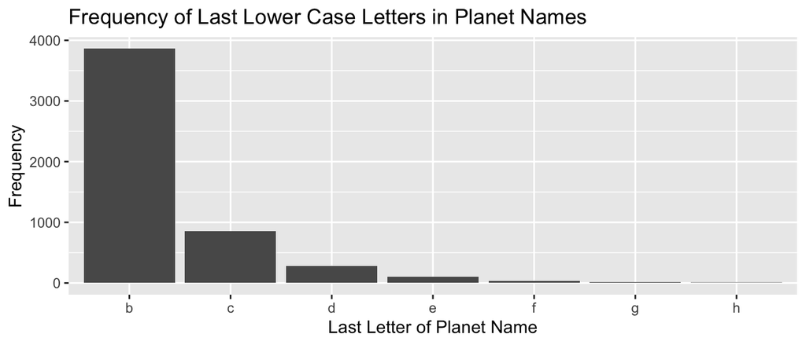

```r
conventional_planets = planets %>%
  filter(str_detect(planet, paste0(star, " [a-z]$")))

last_letter_freq = conventional_planets %>%
  mutate(last_letter = str_extract(planet, "[a-z]$")) %>%
  count(last_letter, sort = TRUE)

ggplot(last_letter_freq, aes(x = last_letter, y = n)) +
  geom_col() +
  labs(x = "Last Letter of Planet Name", y = "Frequency", title = "Frequency of Last Lower Case Letters in Planet Names")
```

8. The file `wordle_data.csv` contains the original solution list to the game Wordle. In the game, players attempt to identify a secret five-letter word by guessing a word and using the color-coded information returned. A green letter from the guess is in the correct location in the secret word. A yellow letter from the guess is in the secret word, but is not in the correct location. A gray letter is not in the word (unless a guess contains multiple copis of the same letter and at least one letter is colored and another is gray).

In a puzzle, the guess information is return for these first two guesses.

- SLATE returns the pattern Gray, Gray, Gray, Yellow, Gray
- COUNT returns the pattern Yellow, Green, Gray, Gray, Yellow

*(Note that the words in the data base have all lower case letters.)*

Find all possible solutions in `wrdl` which are consistent with the information given.

*Hint: you may find it easiest to pipe the word list through multiple `filter()` commands instead of trying to create a single regular expression which only matches all possible solutions. For example, you know the secret word contains at least one `T` and this letter is not in the 4th or 5th positions, at least one `C` which is not the first letter, and that the second letter is an `O`. You also know several letters which are not contained in the secret word.*

```r
wrdl = read_csv("../../data/wordle_data.csv") %>%
  filter(solution == TRUE) %>%
  select(word)

wrdl %>%
  filter(str_sub(word, 2, 2) == "o",
         !(str_sub(word, 4, 4) == "t" | str_sub(word, 5, 5) == "t")) %>%
  filter(str_sub(word, 1, 1) == "g",
         str_sub(word, 2, 2) == "r",
         str_sub(word, 3, 3) != "y",
         str_sub(word, 4, 4) == "g",
         str_sub(word, 5, 5) == "r") %>%
  filter(str_sub(word, 1, 1) == "y",
         str_sub(word, 2, 2) == "g",
         str_sub(word, 3, 3) != "r",
         str_sub(word, 4, 4) != "g",
         str_sub(word, 4, 4) == "y",
         str_sub(word, 5, 5) != "g") %>%
  view
```

[output not shown]